# Acoustic Monitoring on Railways

Comparing sample data from the UK, Spain and Portugal

# Introduction

This report presents an exploratory analysis of acoustic monitoring data collected along railway networks across three countries: UK, Spain and Portugal. Acoustic devices were distributed at three sites per country, with three sensors per site. The devices were located on a mixture of farmland, fen (wetland), woodland, and Mediterranean ago-forestry.

The analysis explores differences in recording effort and the diversity and distribution of species detected through acoustic monitoring. In particular, it examines the number of unique recordings collected in each country, the total recording effort, and the extent to which detected species are shared between countries or are recorded exclusively within one country. We also explore patterns in species detections, including the most frequently detected species, peak recording times and model confidence.

## Recording effort by country

To avoid counting individual species detection’s as separate recordings, unique recordings were identified using the combination of device ID and recording date/time.

### Recording effort for birds

Summary of acoustic recording effort by country (birds)

| Country | Total_recordings | Total_hours |
| --- | --- | --- |
| UK | 142884 | 2378.07 |
| Spain | 47107 | 785.04 |
| Portugal | 72601 | 1207.31 |

### Recording effort for bats

Summary of acoustic recording effort by country (bats)

| Country | Total_recordings | Total_hours |
| --- | --- | --- |
| UK | 53329 | 150.61 |
| Spain | 43390 | 79.62 |
| Portugal | 28430 | 95.63 |

## Species richness

Species richness was calculated as the number of unique scientific names detected in each country. Bat species richness was identical across the three countries, with 17 species detected in each. The number of bird species was relatively similar across the three countries as shown below.

A full list of bird and bat species can be found in the appendix.

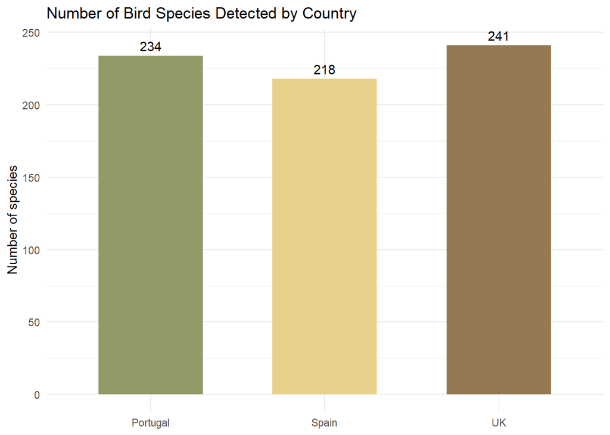

### Species overlap between countries

Species were compared between countries using their scientific names. Each species was assigned to one of seven mutually exclusive distribution groups.A species comparison table can be found in the appendix detailing all identified species, their common names and their distribution across the three countries

Distribution of species across the three countries

| Comparison | Number_of_species |
| --- | --- |
| Shared by all three | 154 |
| UK and Spain only | 22 |
| UK and Portugal only | 17 |
| Spain and Portugal only | 32 |
| UK only | 48 |
| Spain only | 10 |
| Portugal only | 31 |

## Species dominance

To explore which species were most commonly detected by the acoustic monitoring devices, we counted the number of detection records for each species in each country. We then identified the five most frequently detected species for the UK, Spain and Portugal. The charts show what percentage of all identified species detection records in each country came from these five species.

It is important to note that the number of recordings does not necessarily reflect how many individual species are present. Some species may be recorded more often because they call more frequently, are easier to detect, or because of differences in recording conditions. These results therefore show patterns in acoustic detections rather than actual population sizes.

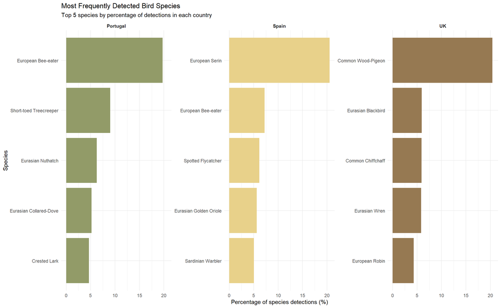

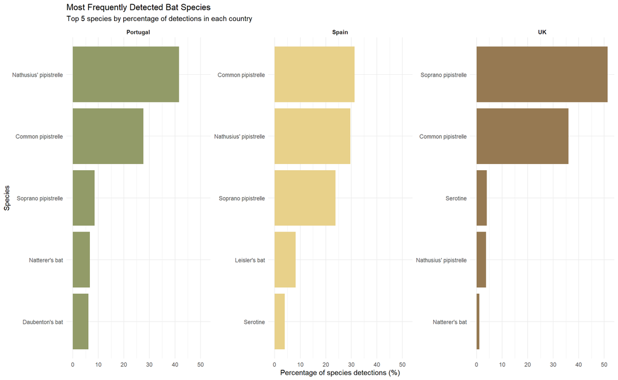

## Species ID confidence

The acoustic monitoring data include a confidence score for each species detection instance. This score indicates how confident the identificaton model was in its classification, with higher scores indicating greater confidence in the predicted species ID. Numerical scores range from 0.25 to 1, and detections are assigned a ‘high’ or ‘low’ confidence flag dependant on their numerical score.

It is important to distinguish model confidence from identification accuracy. A high confidence score does not necessarily mean that the species ID is correct, and a low score does not necessarily mean its incorrect. The scores simply provide an indication of how certain the model was about its prediction as the species detected have not been independently verified.

The following visualisations explore how the confidence scores vary between the countries and also amoung some of the most frequently detected species.

### Confidence scores across countries

The boxplot compares the distribution of model confidence scores across the UK, Spain and Portugal.

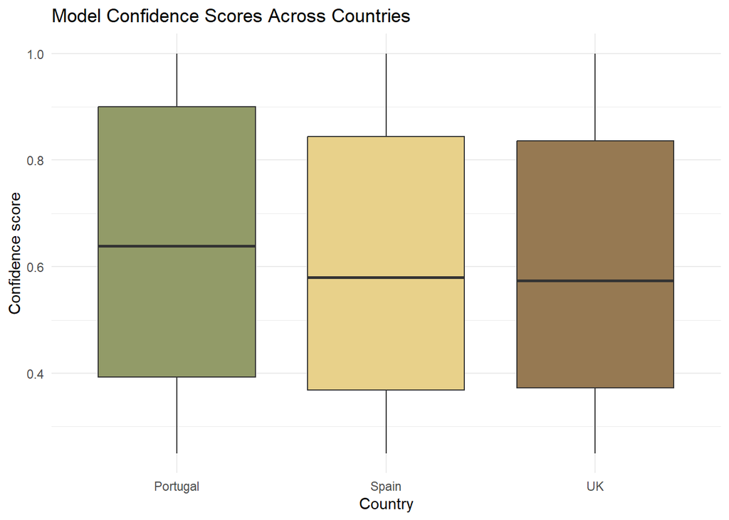

### Confidence scores for the top three dominant species

To explore confidence variance within species, we looked at the three most detected species in each country (identified in the previous section on species dominance). The stacked bars show the percentage of detections assigned ‘high’ and ‘low’ confidence flags for each species. The number alongside each bar indicated the total number of detections of the species in that country.

This comparison highlights that there is variance in the confidence scores within single species, even among those detected frequently. It also allows us to compare the confidence associated with the same species across different countries, as is the case for the European Bee-eater which was in the top three dominant species for Spain and Portugal.

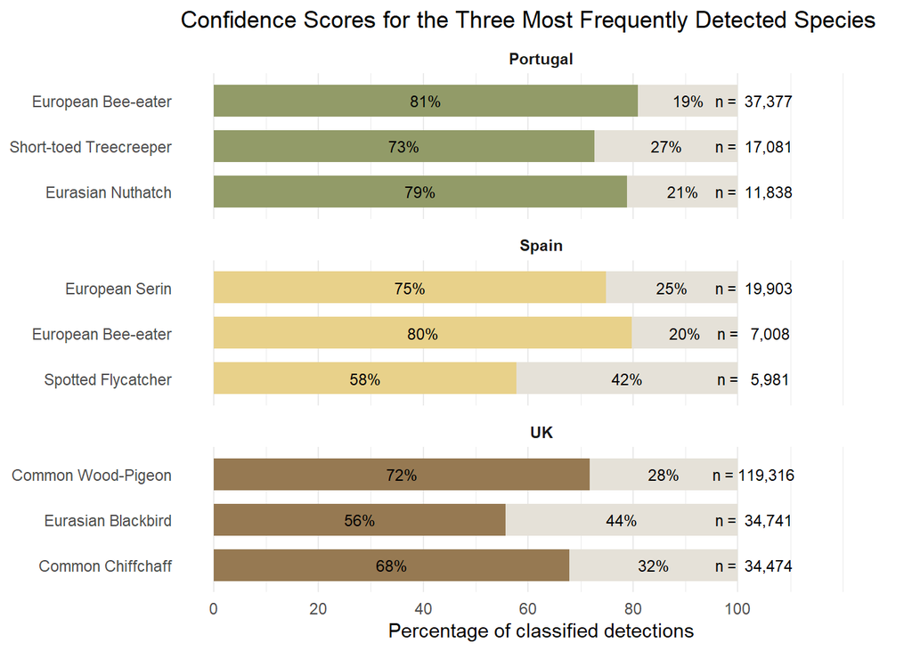

Overall, confidence score distributions were broadly similar across the three countries, although Portugal had a slightly higher median score.

Among the most frequently detected species, the proportion of high-confidence flags varied. However, it’s interesting to see that the European Bee-eater’s confidence was consistent between Spain and Portugal with 81% and 80% of detections flagged as ‘high’ confidence.

These patterns show that the model confidence can vary between species as well as between individual detections. This could relate to species-specific vocalisations, recording conditions, or other factors.

## Peak detection times

To explore when bird species were most frequently detected, we examined the number of identified detection records across the hour of each day. The results are presented using UTC timestamps to allow for comparison between countries.

The highest number of detections occurred between 05:00-06:00 in the UK, 07:00-08:00 in Portugal and 08:00-09:00 in Spain.

The UK recorded more detections overall, including a particularly pronounced early-morning peak. However, the is relative to the higher total recording in the UK in terms of recording hours. Differences in detection totals therefore do not necessarily indicate differences in bird abundance or activity between countries.

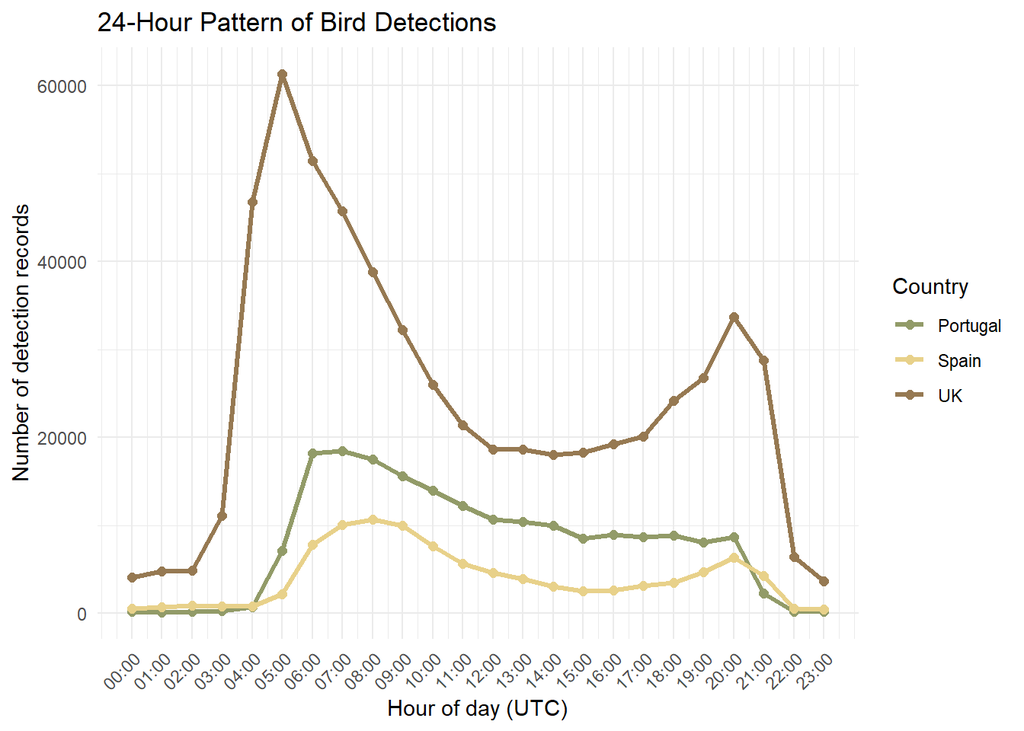

[output not shown]

## Appendix

### Species comparison table

The following table brings together all identified species, their common names and their distribution across the three countries.

Species detected across the UK, Spain and Portugal

| scientific_name | common_name | Distribution |
| --- | --- | --- |
| Acanthis cabaret | Lesser Redpoll | UK only |
| Accipiter gentilis | Northern Goshawk | Shared by all three |
| Accipiter nisus | Eurasian Sparrowhawk | Shared by all three |
| Acrocephalus arundinaceus | Great Reed Warbler | Spain and Portugal only |
| Acrocephalus melanopogon | Moustached Warbler | Spain only |
| Acrocephalus palustris | Marsh Warbler | UK only |
| Acrocephalus schoenobaenus | Sedge Warbler | Shared by all three |
| Acrocephalus scirpaceus | Eurasian Reed Warbler | Shared by all three |
| Actitis hypoleucos | Common Sandpiper | Shared by all three |
| Aegithalos caudatus | Long-tailed Tit | Shared by all three |
| Aegypius monachus | Cinereous Vulture | Portugal only |
| Aix galericulata | Mandarin Duck | UK only |
| Alauda arvensis | Eurasian Skylark | UK and Portugal only |
| Alca torda | Razorbill | UK and Portugal only |
| Alcedo atthis | Common Kingfisher | Shared by all three |
| Alectoris rufa | Red-legged Partridge | Shared by all three |
| Alopochen aegyptiaca | Egyptian Goose | UK only |
| Anas acuta | Northern Pintail | Shared by all three |
| Anas crecca | Green-winged Teal | Shared by all three |
| Anas platyrhynchos | Mallard | Shared by all three |
| Anser albifrons | Greater White-fronted Goose | UK only |
| Anser anser | Graylag Goose | Shared by all three |
| Anser brachyrhynchus | Pink-footed Goose | UK and Portugal only |
| Anthus campestris | Tawny Pipit | Shared by all three |
| Anthus petrosus | Rock Pipit | UK only |
| Anthus pratensis | Meadow Pipit | Shared by all three |
| Anthus spinoletta | Water Pipit | Shared by all three |
| Anthus trivialis | Tree Pipit | Shared by all three |
| Apus apus | Common Swift | Shared by all three |
| Apus melba | Alpine Swift | Spain and Portugal only |

[output cut: 284 more lines]